# BIOS 617 - Lecture 2

1/8/2019

## JITT Review/Discussion

## Simple random sampling (SRS) without replacement

- Generate sample by sampling without replacement
- Given we selected \(j\) *unique* units, the next unit is sampled uniformly at random with probability \(1/(N-j)\).
- There are \({N \choose n} = N! / (n! (N-n)!)\) possible samples
- Sample mean under SRS is unbiased, with variance \((1-f) \frac{S^2}{n}\)

## Unbiasedness of SRS sample mean

- What is the probability of sampling individual \(j\)? \[\small \begin{align*} P(I_j = 1) &= 1 - P(I_j \neq 1) \\ &= 1 - \frac{N-1}{N} \times \frac{N-2}{N-1} \times \cdots \times \frac{N-n}{N-(n-1)} \\ &= 1 - \frac{N-n}{N} = \frac{n}{N} \end{align*} \]
- Then by linearity of expectations \[\small E [ \bar y ] = E \left[ \frac{1}{n} \sum_j I_j Y_j \right] = \frac{1}{n} \sum_j E [ I_j ] Y_j = \bar Y \]

## A slightly more cumbersome proof

We can use the the sampling design directly instead. The number of samples \(S = {N \choose n}\). Then

\[\small \begin{align*} E[ \bar y ] &= \sum_{s=1}^S P_s \bar y_s = \sum_{s=1}^S {N \choose n}^{(-1)} \frac{1}{n} \sum_{j=1}^N I^{(s)}_j Y_j \\ &= \frac{(N-n)!n!}{n \cdot N!} \sum_{j=1}^N Q_j Y_j = \frac{(N-n)!n!}{n \cdot N!} \sum_{j=1}^N {N-1 \choose n-1} Y_j \\ &= \frac{(N-n)!n!}{n \cdot N!} \frac{(N-1)!}{(n-1)! (N-n)!} \sum_{j=1}^N Y_j \\ &= \frac{1}{N} \sum_{j=1}^N Y_j \\ \end{align*} \]

## Variance of \(\bar y\)

\[ \small \begin{align*} &E \left[ \left( \bar y - \bar Y \right)^2 \right] \\ = &E \left[ \left( n^{-1} \sum_{j=1}^N I_j^{(s)} (Y_i - \bar Y) \right)^2 \right] \\ = &\frac{1}{n^2} \left( \sum_{i,j=1}^N E \left[I_i^{(s)} I_j^{(s)} \right] (Y_i - \bar Y) (Y_j - \bar Y) \right) \\ = &\frac{1}{n^2} \left( \sum_{i}^N \frac{n}{N} (Y_i - \bar Y)^2 + \sum_{i \neq j} \frac{n}{N} \cdot \frac{n-1}{N-1} (Y_i - \bar Y) (Y_j - \bar Y) \right) \\ = &\frac{1}{n \cdot N} \left( \left(1 - \frac{n-1}{N-1} \right) \sum_{i}^N (Y_i - \bar Y)^2 + \frac{n-1}{N-1}\left[ \sum_{i=1}^N (Y_i - \bar Y) \right]^2 \right) \\ = &\frac{N-n}{N} \frac{S^2}{n} + 0 = (1-f)\frac{S^2}{n} \end{align*} \]

## Method 2: Symmetry arguments

Let's use prior class results on variance directly \[ \small \begin{align*} V(\bar y) = &V \left( n{-1} \sum_{i=1}^n y_i \right) = \frac{1}{n^2} V \left( \sum_{i=1}^n y_i \right) \\ &= \frac{1}{n^2} \left[ n \cdot V(y_i) + n \cdot (n-1) \cdot \text{Cov} (y_i, y_j) \right] \\ &= \frac{1}{n^2} \left[ n \cdot \frac{N-1}{N} S^2 + n \cdot (n-1) \left( E[y_i y_j] - \bar Y^2 \right) \right] \end{align*} \]

## Method 2: Computing moments

\[ \small \begin{align*} E[y_i y_j ] &= E \left[ \frac{y_j}{N-1} \sum_{i=1, i \neq j}^N Y_i \right] = E \left[ \frac{y_j}{N-1} (N \bar Y - y_j) \right]\\ &= \frac{1}{N-1} \left( N \bar Y^2 - E [ y_j^2 ] \right) = \frac{1}{N-1} \left( N \bar Y^2 - \bar Y^2 - \frac{N-1}{N} S^2 \right) \\ &= \bar Y^2 - \frac{S^2}{N} \end{align*} \] So the \(\text{Cov} (y_i, y_j) = - \frac{S^2}{N}\) and \[ V(\bar y) = \frac{1}{n} \left[ (N-1)\frac{S^2}{N} - (n-1) \frac{S^2}{N} \right] = \frac{S^2}{n} (1-f). \]

## Simulation study (ctd.)

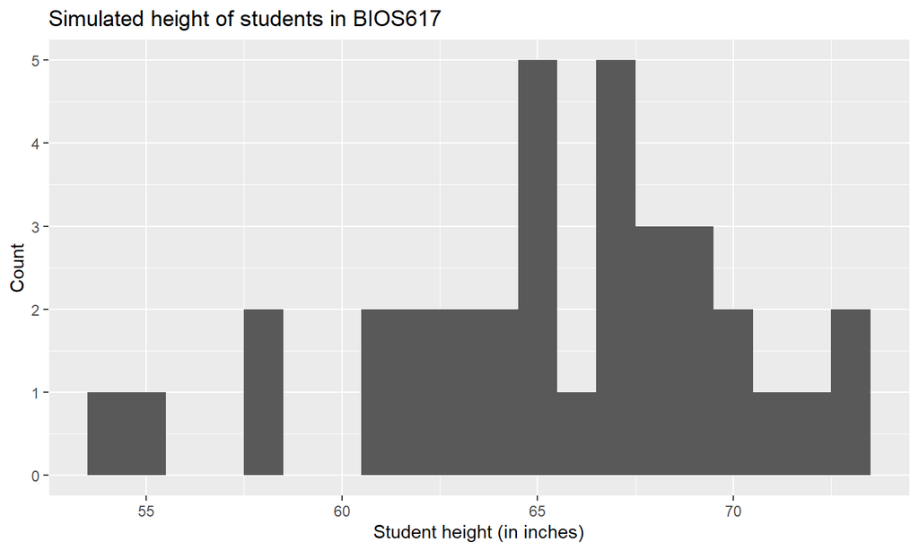